# MovieLens Project Questions-Copy1

### Project - MovieLens Data Analysis

The GroupLens Research Project is a research group in the Department of Computer Science and Engineering at the University of Minnesota. The data is widely used for collaborative filtering and other filtering solutions. However, we will be using this data to act as a means to demonstrate our skill in using Python to “play” with data.

### Datasets Information:

- Data.csv: It contains information of ratings given by the users to a particular movie. Columns: user id, movie id, rating, timestamp
- item.csv: File contains information related to the movies and its genre.
- Columns: movie id, movie title, release date, unknown, Action, Adventure, Animation, Children’s, Comedy, Crime, Documentary, Drama, Fantasy, Film-Noir, Horror, Musical, Mystery, Romance, Sci-Fi, Thriller, War, Western
- user.csv: It contains information of the users who have rated the movies. Columns: user id, age, gender, occupation, zip code

### Objective:

`To implement the techniques learnt as a part of the course.`

### Learning Outcomes:

- Exploratory Data Analysis
- Visualization using Python
- Pandas – groupby, merging

#### Domain

`Internet and Entertainment`

**Note that the project will need you to apply the concepts of groupby and merging extensively.**

#### 1. Import the necessary packages - 2.5 marks

```python
from IPython.display import display #import IPython display to display multiple charts per cell
import pandas as pd #data access and manipulation package
import seaborn as sns #pretty charts package
import matplotlib.pyplot as plt #requirement for seaborn package
sns.set(color_codes = True) #make charts prettier
%matplotlib inline #display charts
```

```
UsageError: unrecognized arguments: #display charts
```

#### 2. Read the 3 datasets into dataframes - 2.5 marks

```python
dataDF = pd.read_csv('Data.csv') #read in data.csv
itemDF = pd.read_csv('item.csv') #read in item.csv
userDF = pd.read_csv('user.csv') #read in user.csv
```

#### 3. Apply info, shape, describe, and find the number of missing values in the data - 5 marks

- Note that you will need to do it for all the three datasets seperately

```python
#information on data file dataframe
print("Data.csv Info\n--------------------")
dataDF.info()
print("\n")
print("Data.csv Shape\n--------------------")
print(dataDF.shape)
print("\n")
print("Data.csv Description\n--------------------")
dataDF.describe()
```

```
Data.csv Info
--------------------
<class 'pandas.core.frame.DataFrame'>
RangeIndex: 100000 entries, 0 to 99999
Data columns (total 4 columns):
 #   Column     Non-Null Count   Dtype
---  ------     --------------   -----
 0   user id    100000 non-null  int64
 1   movie id   100000 non-null  int64
 2   rating     100000 non-null  int64
 3   timestamp  100000 non-null  int64
dtypes: int64(4)
memory usage: 3.1 MB


Data.csv Shape
--------------------
(100000, 4)


Data.csv Description
--------------------
```

|  | user id | movie id | rating | timestamp |
| --- | --- | --- | --- | --- |
| count | 100000.00000 | 100000.000000 | 100000.000000 | 1.000000e+05 |
| mean | 462.48475 | 425.530130 | 3.529860 | 8.835289e+08 |
| std | 266.61442 | 330.798356 | 1.125674 | 5.343856e+06 |
| min | 1.00000 | 1.000000 | 1.000000 | 8.747247e+08 |
| 25% | 254.00000 | 175.000000 | 3.000000 | 8.794487e+08 |
| 50% | 447.00000 | 322.000000 | 4.000000 | 8.828269e+08 |
| 75% | 682.00000 | 631.000000 | 4.000000 | 8.882600e+08 |
| max | 943.00000 | 1682.000000 | 5.000000 | 8.932866e+08 |

```python
#information on item file dataframe
print("Data.csv Info\n--------------------")
itemDF.info()
print("\n")
print("Data.csv Shape\n--------------------")
print(itemDF.shape)
print("\n")
print("Data.csv Description\n--------------------")
itemDF.describe()
```

```
Data.csv Info
--------------------
<class 'pandas.core.frame.DataFrame'>
RangeIndex: 1681 entries, 0 to 1680
Data columns (total 22 columns):
 #   Column        Non-Null Count  Dtype
---  ------        --------------  -----
 0   movie id      1681 non-null   int64
 1   movie title   1681 non-null   object
 2   release date  1681 non-null   object
 3   unknown       1681 non-null   int64
 4   Action        1681 non-null   int64
 5   Adventure     1681 non-null   int64
 6   Animation     1681 non-null   int64
 7   Childrens     1681 non-null   int64
 8   Comedy        1681 non-null   int64
 9   Crime         1681 non-null   int64
 10  Documentary   1681 non-null   int64
 11  Drama         1681 non-null   int64
 12  Fantasy       1681 non-null   int64
 13  Film-Noir     1681 non-null   int64
 14  Horror        1681 non-null   int64
 15  Musical       1681 non-null   int64
 16  Mystery       1681 non-null   int64
 17  Romance       1681 non-null   int64
 18  Sci-Fi        1681 non-null   int64
 19  Thriller      1681 non-null   int64
 20  War           1681 non-null   int64
 21  Western       1681 non-null   int64
dtypes: int64(20), object(2)
memory usage: 289.0+ KB


Data.csv Shape
--------------------
(1681, 22)


Data.csv Description
--------------------
```

|  | movie id | unknown | Action | Adventure | Animation | Childrens | Comedy | Crime | Documentary | Drama | Fantasy | Film-Noir | Horror | Musical | Mystery | Romance | Sci-Fi | Thriller | War | Western |
| --- | --- | --- | --- | --- | --- | --- | --- | --- | --- | --- | --- | --- | --- | --- | --- | --- | --- | --- | --- | --- |
| count | 1681.000000 | 1681.000000 | 1681.000000 | 1681.000000 | 1681.000000 | 1681.000000 | 1681.000000 | 1681.000000 | 1681.000000 | 1681.000000 | 1681.000000 | 1681.000000 | 1681.000000 | 1681.000000 | 1681.000000 | 1681.000000 | 1681.000000 | 1681.000000 | 1681.000000 | 1681.000000 |
| mean | 841.841761 | 0.000595 | 0.149316 | 0.080309 | 0.024985 | 0.072576 | 0.300416 | 0.064842 | 0.029744 | 0.431291 | 0.013087 | 0.014277 | 0.054729 | 0.033314 | 0.036288 | 0.146936 | 0.060083 | 0.149316 | 0.042237 | 0.016062 |
| std | 485.638077 | 0.024390 | 0.356506 | 0.271852 | 0.156126 | 0.259516 | 0.458576 | 0.246321 | 0.169931 | 0.495404 | 0.113683 | 0.118667 | 0.227519 | 0.179507 | 0.187061 | 0.354148 | 0.237712 | 0.356506 | 0.201189 | 0.125751 |
| min | 1.000000 | 0.000000 | 0.000000 | 0.000000 | 0.000000 | 0.000000 | 0.000000 | 0.000000 | 0.000000 | 0.000000 | 0.000000 | 0.000000 | 0.000000 | 0.000000 | 0.000000 | 0.000000 | 0.000000 | 0.000000 | 0.000000 | 0.000000 |
| 25% | 422.000000 | 0.000000 | 0.000000 | 0.000000 | 0.000000 | 0.000000 | 0.000000 | 0.000000 | 0.000000 | 0.000000 | 0.000000 | 0.000000 | 0.000000 | 0.000000 | 0.000000 | 0.000000 | 0.000000 | 0.000000 | 0.000000 | 0.000000 |
| 50% | 842.000000 | 0.000000 | 0.000000 | 0.000000 | 0.000000 | 0.000000 | 0.000000 | 0.000000 | 0.000000 | 0.000000 | 0.000000 | 0.000000 | 0.000000 | 0.000000 | 0.000000 | 0.000000 | 0.000000 | 0.000000 | 0.000000 | 0.000000 |
| 75% | 1262.000000 | 0.000000 | 0.000000 | 0.000000 | 0.000000 | 0.000000 | 1.000000 | 0.000000 | 0.000000 | 1.000000 | 0.000000 | 0.000000 | 0.000000 | 0.000000 | 0.000000 | 0.000000 | 0.000000 | 0.000000 | 0.000000 | 0.000000 |
| max | 1682.000000 | 1.000000 | 1.000000 | 1.000000 | 1.000000 | 1.000000 | 1.000000 | 1.000000 | 1.000000 | 1.000000 | 1.000000 | 1.000000 | 1.000000 | 1.000000 | 1.000000 | 1.000000 | 1.000000 | 1.000000 | 1.000000 | 1.000000 |

```python
#information on user file dataframe
print("Data.csv Info\n--------------------")
userDF.info()
print("\n")
print("Data.csv Shape\n--------------------")
print(userDF.shape)
print("\n")
print("Data.csv Description\n--------------------")
userDF.describe()
```

```
Data.csv Info
--------------------
<class 'pandas.core.frame.DataFrame'>
RangeIndex: 943 entries, 0 to 942
Data columns (total 5 columns):
 #   Column      Non-Null Count  Dtype
---  ------      --------------  -----
 0   user id     943 non-null    int64
 1   age         943 non-null    int64
 2   gender      943 non-null    object
 3   occupation  943 non-null    object
 4   zip code    943 non-null    object
dtypes: int64(2), object(3)
memory usage: 37.0+ KB


Data.csv Shape
--------------------
(943, 5)


Data.csv Description
--------------------
```

|  | user id | age |
| --- | --- | --- |
| count | 943.000000 | 943.000000 |
| mean | 472.000000 | 34.051962 |
| std | 272.364951 | 12.192740 |
| min | 1.000000 | 7.000000 |
| 25% | 236.500000 | 25.000000 |
| 50% | 472.000000 | 31.000000 |
| 75% | 707.500000 | 43.000000 |
| max | 943.000000 | 73.000000 |

#### 4. Find the number of movies per genre using the item data - 2.5 marks

```python
# use sum on the default axis
# genres start in column 4
headerArray = ["Genre","# of Movies"]
for item in headerArray:
    print(item, end='      ')
print("")
print(itemDF.iloc[:,3:].sum(axis=0))
```

```
Genre      # of Movies
unknown          1
Action         251
Adventure      135
Animation       42
Childrens      122
Comedy         505
Crime          109
Documentary     50
Drama          725
Fantasy         22
Film-Noir       24
Horror          92
Musical         56
Mystery         61
Romance        247
Sci-Fi         101
Thriller       251
War             71
Western         27
dtype: int64
```

#### 5. Find the movies that have more than one genre - 5 marks

```python
#hint: use sum on the axis = 1

#create dataframe with genre sum totals
totalsDF = itemDF.iloc[:,3:].sum(axis=1)
#show only item rows where total genres are greater than 1
itemDF.iloc[totalsDF[totalsDF > 1].index]
```

|  | movie id | movie title | release date | unknown | Action | Adventure | Animation | Childrens | Comedy | Crime | ... | Fantasy | Film-Noir | Horror | Musical | Mystery | Romance | Sci-Fi | Thriller | War | Western |
| --- | --- | --- | --- | --- | --- | --- | --- | --- | --- | --- | --- | --- | --- | --- | --- | --- | --- | --- | --- | --- | --- |
| 0 | 1 | Toy Story | 01-Jan-1995 | 0 | 0 | 0 | 1 | 1 | 1 | 0 | ... | 0 | 0 | 0 | 0 | 0 | 0 | 0 | 0 | 0 | 0 |
| 1 | 2 | GoldenEye | 01-Jan-1995 | 0 | 1 | 1 | 0 | 0 | 0 | 0 | ... | 0 | 0 | 0 | 0 | 0 | 0 | 0 | 1 | 0 | 0 |
| 3 | 4 | Get Shorty | 01-Jan-1995 | 0 | 1 | 0 | 0 | 0 | 1 | 0 | ... | 0 | 0 | 0 | 0 | 0 | 0 | 0 | 0 | 0 | 0 |
| 4 | 5 | Copycat | 01-Jan-1995 | 0 | 0 | 0 | 0 | 0 | 0 | 1 | ... | 0 | 0 | 0 | 0 | 0 | 0 | 0 | 1 | 0 | 0 |
| 6 | 7 | Twelve Monkeys | 01-Jan-1995 | 0 | 0 | 0 | 0 | 0 | 0 | 0 | ... | 0 | 0 | 0 | 0 | 0 | 0 | 1 | 0 | 0 | 0 |
| ... | ... | ... | ... | ... | ... | ... | ... | ... | ... | ... | ... | ... | ... | ... | ... | ... | ... | ... | ... | ... | ... |
| 1667 | 1669 | MURDER and murder | 20-Jun-1997 | 0 | 0 | 0 | 0 | 0 | 0 | 1 | ... | 0 | 0 | 0 | 0 | 1 | 0 | 0 | 0 | 0 | 0 |
| 1668 | 1670 | Tainted | 01-Feb-1998 | 0 | 0 | 0 | 0 | 0 | 1 | 0 | ... | 0 | 0 | 0 | 0 | 0 | 0 | 0 | 1 | 0 | 0 |
| 1671 | 1673 | Mirage | 01-Jan-1995 | 0 | 1 | 0 | 0 | 0 | 0 | 0 | ... | 0 | 0 | 0 | 0 | 0 | 0 | 0 | 1 | 0 | 0 |
| 1677 | 1679 | B. Monkey | 06-Feb-1998 | 0 | 0 | 0 | 0 | 0 | 0 | 0 | ... | 0 | 0 | 0 | 0 | 0 | 1 | 0 | 1 | 0 | 0 |
| 1678 | 1680 | Sliding Doors | 01-Jan-1998 | 0 | 0 | 0 | 0 | 0 | 0 | 0 | ... | 0 | 0 | 0 | 0 | 0 | 1 | 0 | 0 | 0 | 0 |

849 rows × 22 columns

#### 6. Drop the movie where the genre is unknown - 2.5 marks

```python
#get row indexes where genre is unknown
unknownDF = itemDF[itemDF['unknown'] == 1].index

#print unknown genre movie name
print(itemDF.iloc[unknownDF]['movie title'])

#drop unknown movie genre movies
itemDF.drop(unknownDF, inplace=True)
```

```
1371    Good Morning
Name: movie title, dtype: object
```

### 7. Univariate plots of columns: 'rating', 'Age', 'release year', 'Gender' and 'Occupation' - 10 marks

```python
# HINT: use distplot for age and countplot for gender,ratings,occupation, release year.
# HINT: Please refer to the below snippet to understand how to get to release year from release date. You can use str.split()
# as depicted below.
```

```python
a = 'My*cat*is*brown'
print(a.split('*')[3])

#similarly, the release year needs to be taken out from release date

#also you can simply slice existing string to get the desired data, if we want to take out the colour of the cat

print(a[10:])
print(a[-5:])
```

```
brown
brown
brown
```

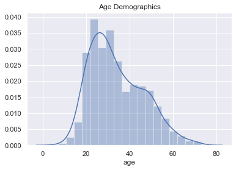

```python
#plot age demographics
sns.distplot(userDF['age']).set_title('Age Demographics')
```

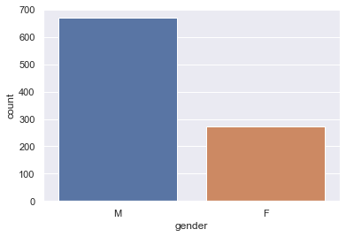

```python
#plot gender data
sns.countplot(userDF['gender'])
```

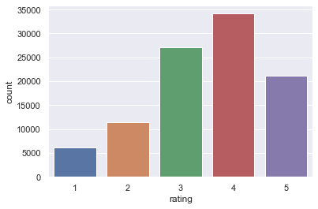

```python
#plot rating data
sns.countplot(dataDF['rating'])
```

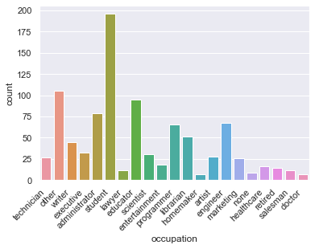

```python
#create countplot and set as variable occupation plot
occupationPlot = sns.countplot(userDF['occupation'])

#make pretty as below
#retrieve x axis labels, rotate them 45 degrees, and align right to fix center justification
#store label strings returned from set_xticklabels function in value so that they do not print
values = occupationPlot.set_xticklabels(occupationPlot.get_xticklabels(), rotation=45, horizontalalignment='right')
```

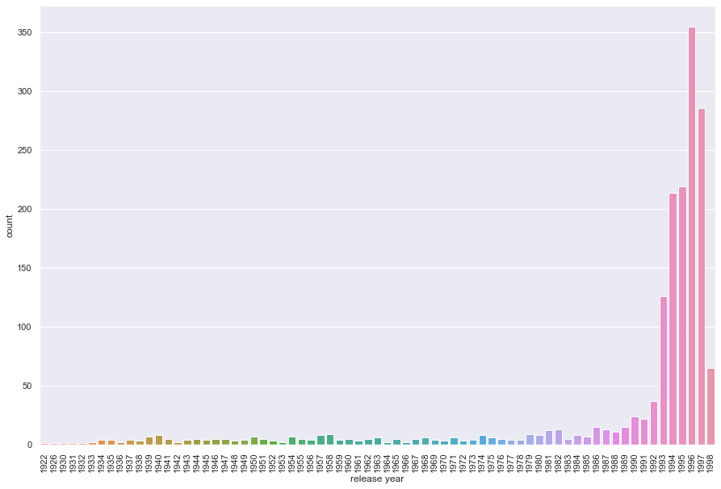

```python
#create copy of item dataframe
releaseYearDF = itemDF.copy()

#create release year list
releaseYearList = itemDF['release date'].str.split('-', expand=True)[2]

#insert release year column after release date
releaseYearDF.insert(3,'release year',releaseYearList)

#make a larger dimension chart by creation matplotlib axis and setting increased dimensions
dims = (15, 10)
fig, ax = plt.subplots(figsize=dims)

#create countplot and set as variable occupation plot
releaseYearPlot = sns.countplot(releaseYearDF['release year'],ax=ax)

#make pretty as below
#retrieve x axis labels, rotate them 45 degrees
#store label strings returned from set_xticklabels function in value so that they do not print
values = releaseYearPlot.set_xticklabels(releaseYearPlot.get_xticklabels(), rotation=90)
```

### 8. Visualize how popularity of genres has changed over the years - 10 marks

Note that you need to use the number of releases in a year as a parameter of popularity of a genre

Hint

1: you need to reach to a data frame where the release year is the index and the genre is the column names (one cell shows the number of release in a year in one genre) or vice versa. Once that is achieved, you can either use multiple bivariate plots or can use the heatmap to visualise all the changes over the years in one go.

Hint 2: Use groupby on the relevant column and use sum() on the same to find out the nuumber of releases in a year/genre.

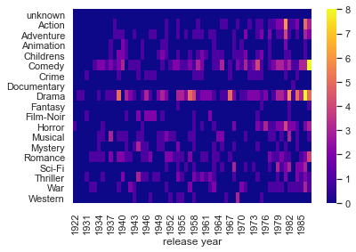

```python
#create new dataframe
itemReleaseYearDF = itemDF.copy()

#create release year list
releaseYearList = itemDF['release date'].str.split('-', expand=True)[2]

#insert release year column after release date
itemReleaseYearDF.insert(3,'release year',releaseYearList)

#create heatmap for before 1993 and store the return value so that it does not print
rval1 = sns.heatmap(itemReleaseYearDF[itemReleaseYearDF['release year'].astype(int) < 1988].iloc[:,3:].groupby(['release year']).sum().transpose(), cmap ="plasma", yticklabels=True)
```

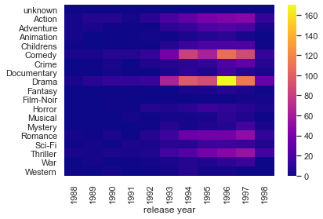

```python
#create heatmap for 1988 or later and store the return value so that it does not print
rval2 = sns.heatmap(itemReleaseYearDF[itemReleaseYearDF['release year'].astype(int) > 1987].iloc[:,3:].groupby(['release year']).sum().transpose(), cmap ="plasma", yticklabels=True)
```

### 9. Find the top 25 movies according to average ratings such that each movie has number of ratings more than 100 - 10 marks

Hint :

1. First find the movies that have more than 100 ratings(use merge, groupby and count). Extract the movie id in a list.
2. Find the average rating of all the movies and sort them in the descending order. You will have to use the .merge() function to reach to a data set through which you can get the ids and the average rating.
3. Use isin(list obtained from 1) to filter out the movies which have more than 100 ratings.

Note: This question will need you to research about groupby and apply your findings. You can find more on groupby on https://realpython.com/pandas-groupby/.

```python
#create top movie rating dataframe
topMoviesDF = dataDF.groupby('movie id').agg(avg=('rating', 'mean'), count=('rating', 'count')).reset_index()

#filter for movies with more than 100 ratings
topMoviesDF = topMoviesDF[topMoviesDF['count'] > 100]


#create dataframe with merged items and movie rating based on movie id
top25DF = pd.merge(itemDF,topMoviesDF[['movie id','avg','count']],how="outer", on='movie id').dropna().sort_values(by='avg', ascending=False)

#change count from float to int then rename avg to stars because it bothers me
top25DF['count'] = top25DF['count'].astype(int)
top25DF = top25DF.rename(columns={'avg' : 'stars'}).reset_index()

#print top 25
top25DF[['movie title', 'stars']].head(25)
```

|  | movie title | stars |
| --- | --- | --- |
| 0 | Close Shave, A | 4.491071 |
| 1 | Schindler's List | 4.466443 |
| 2 | Wrong Trousers, The | 4.466102 |
| 3 | Casablanca | 4.456790 |
| 4 | Shawshank Redemption, The | 4.445230 |
| 5 | Rear Window | 4.387560 |
| 6 | Usual Suspects, The | 4.385768 |
| 7 | Star Wars | 4.358491 |
| 8 | 12 Angry Men | 4.344000 |
| 9 | Citizen Kane | 4.292929 |
| 10 | To Kill a Mockingbird | 4.292237 |
| 11 | One Flew Over the Cuckoo's Nest | 4.291667 |
| 12 | Silence of the Lambs, The | 4.289744 |
| 13 | North by Northwest | 4.284916 |
| 14 | Godfather, The | 4.283293 |
| 15 | Secrets & Lies | 4.265432 |
| 16 | Good Will Hunting | 4.262626 |
| 17 | Manchurian Candidate, The | 4.259542 |
| 18 | Dr. Strangelove or: How I Learned to Stop Worr... | 4.252577 |
| 19 | Raiders of the Lost Ark | 4.252381 |
| 20 | Vertigo | 4.251397 |
| 21 | Titanic | 4.245714 |
| 22 | Lawrence of Arabia | 4.231214 |
| 23 | Maltese Falcon, The | 4.210145 |
| 24 | Empire Strikes Back, The | 4.204360 |

### 10. See gender distribution across different genres check for the validity of the below statements - 10 marks

- Men watch more drama than women
- Women watch more Sci-Fi than men
- Men watch more Romance than women
1. There is no need to conduct statistical tests around this. Just compare the percentages and comment on the validity of the above statements.
2. you might want ot use the .sum(), .div() function here.
3. Use number of ratings to validate the numbers. For example, if out of 4000 ratings received by women, 3000 are for drama, we will assume that 75% of the women watch drama.

#### Conclusion:

```python
#create dataframe with genre, movie id, and user id
firstDF = pd.merge(itemDF,dataDF[['movie id','user id']], how='outer', on='movie id').dropna()

#create dataframe with genre, movie id, user id, and gender
secondDF = pd.merge(firstDF,userDF[['user id', 'gender']], how='outer', on='user id').dropna()

#get percentage of movies men and women watch that are drama movies
#secondDF[['Drama','gender']].groupby(['gender']).mean().sort_values(by='Drama', ascending=False)

#second try
thirdDF = secondDF[['Drama','gender']].groupby(['gender']).agg(avg=('Drama', 'mean'), count=('Drama', 'sum')).sort_values(by='avg', ascending=False)
thirdDF.rename(columns={'avg' : '% of Total', 'count' : 'Total Number'}).reset_index()
```

|  | gender | % of Total | Total Number |
| --- | --- | --- | --- |
| 0 | F | 0.427694 | 11008.0 |
| 1 | M | 0.389040 | 28887.0 |

Women watch a higher percentage of drama, but men have watched more total drama movies.

```python
#create a dataframe grouped by gender and contains both the mean and count of sci-fi films
thirdDF = secondDF[['Sci-Fi','gender']].groupby(['gender']).agg(avg=('Sci-Fi', 'mean'), count=('Sci-Fi', 'sum')).sort_values(by='avg', ascending=False)

#rename the columns for prettiness
thirdDF.rename(columns={'avg' : '% of Total', 'count' : 'Total Number'}).reset_index()
```

|  | gender | % of Total | Total Number |
| --- | --- | --- | --- |
| 0 | M | 0.136037 | 10101.0 |
| 1 | F | 0.102145 | 2629.0 |

```python
#create a dataframe grouped by gender and contains both the mean and count of romance films
thirdDF = secondDF[['Romance','gender']].groupby(['gender']).agg(avg=('Romance', 'mean'), count=('Romance', 'sum')).sort_values(by='avg', ascending=False)

#rename the columns for prettiness
thirdDF.rename(columns={'avg' : '% of Total', 'count' : 'Total Number'}).reset_index()
```

|  | gender | % of Total | Total Number |
| --- | --- | --- | --- |
| 0 | F | 0.227601 | 5858.0 |
| 1 | M | 0.183200 | 13603.0 |

While women watch a higher percentage of romance movies, men have watched more total romance movies.